# Trabalho CE 2

Juliana Degani

outubro/2019

# Radar chart

O gráfico de radar é também conhecido como gráfico de teia ou gráfico polar é equivalente a um gráfico de coordenadas paralelas, com os eixos dispostos radialmente, onde cada raio representando uma das variáveis e cada estrela representa uma única observação.

Esse gráfico pode ser usado para responder às seguintes perguntas:

- Quais observações são mais semelhantes, ou seja, existem grupos de observações?
- Existem discrepâncias?

No R studio é necessário utulizar o pacote “library(fmsb)”

# Código exemplo de um gráfico simples

- Criar um data frame com as notas de um determinado aluno

```r
notas <- as.data.frame(matrix(c(10,7, 8 ,0 ,9, 1, 5), ncol=7))
colnames(notas) <-  c("Matemática", "Física", "Química" , "Ciências",
                      "História", "Geografia", "Português")
```

- para usar o pacote, temos que adicionar duas linhas no dataframe:
  - as notas mínimas e máximas de cada matéria

```r
notas <- rbind(rep(10,7) , rep(0,7) , notas)
```

- Os dados devem estar organizados da seguinte maneira:

Notas do aluno

| Matemática | Física | Química | Ciências | História | Geografia | Português |
| --- | --- | --- | --- | --- | --- | --- |
| 10 | 10 | 10 | 10 | 10 | 10 | 10 |
| 0 | 0 | 0 | 0 | 0 | 0 | 0 |
| 10 | 7 | 8 | 0 | 9 | 1 | 5 |

# Como fica o gráfico

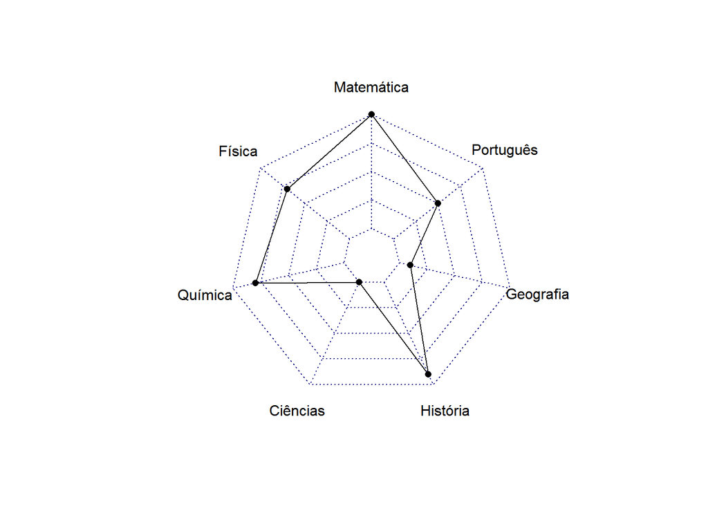

```r
radarchart(notas)
```

# Customizar

- com relação ao polígono é possível aterar:
  - A cor da linha: pcol
  - A cor de preenchimento: pfcol
  - A largura da linha: plwd
- Com relação à grade é possível alterar:
  - A cor da rede: cgcol
  - Tipo de linha: cglty
  - cor dos rótulos dos eixos; axisbcol
  - largura da rede: cglwd
- com relação aos labels:
  - Tamanho dos rótulos dos grupos: vlcex

# Resultado:

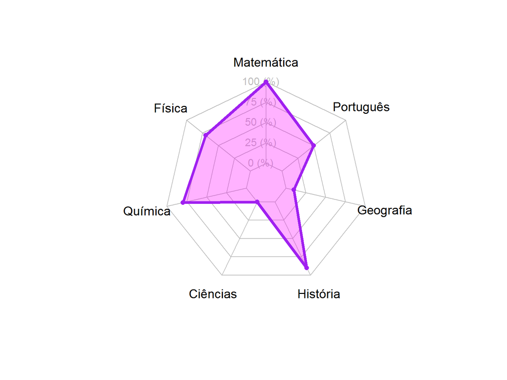

```r
radarchart( notas , axistype=1 ,

  # polígono:
  pcol="purple" ,          # altera a cor da linha
  pfcol= rgb(1,0,1, 0.3) , # altera a cor do preenchimento
                           # rgb: vermelho, verde e azul
  plwd=4 ,                 # altera a largura da linha

  # grade
  cglcol="grey",               # 3 cor da rede
  cglty=1,                     # tipo de linha
  axislabcol="grey",           # cor dos rótulos dos eixos
  cglwd=1,                     # largura da rede

  # rótulos
  vlcex=1.2 # tamanho dos rótulos
)
```

# Comparações:

Criar os dados das notas de 3 alunos:

```r
turma <- as.data.frame(matrix( sample( 0:15, 21 , replace=T) , ncol=7))

colnames(turma) <- c("Matemática", "Física", "Química" , "Ciências",
                     "História", "Geografia", "Português")
rownames(turma) <- paste("Aluno" , letters[1:3] , sep="_")
```

Criar os máximos e mínimos de cada nota: (Reparem que dessa vez as notas variam de 0 a 15)

```r
turma <- rbind(rep(15,7) , rep(0,7) , turma)
```

Criar as 3 cores que queremos usar com o comando rgb

```r
cor_linha=c( rgb(0.2,0.5,0.5,1), rgb(0.8,0.2,0.5,1) , rgb(0.7,0.5,0.1,1) )
cor_preenchimento=c( rgb(0.2,0.5,0.5,0.3), rgb(0.8,0.2,0.5,0.3) , rgb(0.7,0.5,0.1,0.3) )
```

Customiazações finais:

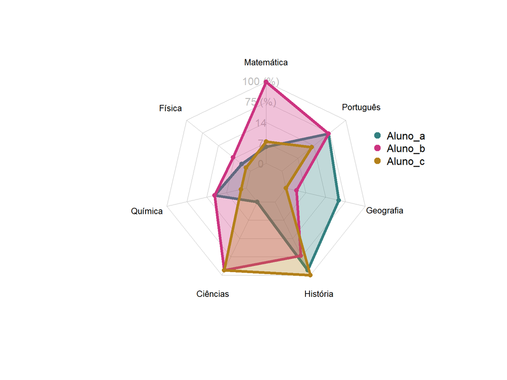

```r
radarchart( turma  , axistype=1 ,
            # polígono
            pcol=cor_linha , pfcol=cor_preenchimento , plwd=4 , plty=1,
            # grade:
            cglcol="grey", cglty=1, axislabcol="grey", caxislabels=seq(0,15,7), cglwd=0.8,
            # rótulos
            vlcex=0.8
)
# Legenda

legend(x=1, y=0.6, # posição
       legend = rownames(turma[-c(1,2),]),
       bty = "n", pch=20 # formato
       , col=cor_linha , text.col = "black", cex=1, # distrância entre as legendas
       pt.cex=2) # tamanho
```